# Algoritmo EM em Modelos de Misturas

Autor

Milena Paz Freitas

# 1. Formulação do Modelo como Estrutura de Dados Incompletos

Como descrito por McLachlan; Krishnan (2008), a mistura (univariada) com $n$ dados observados $\bm y=(y_1,...,y_n)$ pode ser formulada pela composição com uma variável $\bm Z$ latente que indique a qual “grupo” cada observação pertence, de forma que os dados completos sejam $\bm{y_c}= (\bm y^\intercal,\bm z^\intercal)$. Essa formulação se inspira em um método de geração de misturas que, de acordo com Basso; Dávila (2010), considera uma variável aleatória $\bm Z_i$ categórica e $g$-dimensional pela qual a densidade de $Y_i$ é condicionada:

$$Z_{ij}=
\begin{cases}
1\text{, se } Y_i\text{ pertence ao grupo } j
\\
0\text{, c.c.}
\end{cases};\quad j=1,...,g.\quad i=1,...,n.$$
Ou seja, $\bm Z_i$ é multinomial com pesos $\bm p=(p_1,...,p_g)$ e tamanho $n=1$. Logo, sua função de probabilidades (marginal) é dada por: $\text{ }p(\bm z_i)= \prod^g_{j=1} p_j^{z_{ij}}$. Assim, podemos dizer que a função densidade de probabilidade de $Y_i$ condicionada por $\bm Z_i$ é:

$$f(y_i|\bm\theta,\bm z_i)= \prod^g_{j=1}p_j^{z_{ij}}f_j(y_i|\bm \theta_j)^{z_{ij}},$$

onde $\theta_j$ são os parâmetros de $y_i$ correspondentes ao grupo $j$ e $f_j$ as densidades componentes da mistura. A função de verossimilhança completa, considerando $Y_i$ independentes e identicamente distribuidos, seria:

$$L_c(\bm p, \bm \theta)=\prod^n_{i=1}\prod^g_{j=1}\left[p_jf_j(y_i|\bm \theta_j)\right]^{z_{ij}}$$

Logo:

$$l_c(\bm p,\bm\theta)= \sum^g_{j=1}\sum^n_{i=1}z_{ij}\left[\log p_j+\log f_j(y_i|\bm \theta_j)\right]$$

é a log-verossimilhança completa.

# 2. Algoritmo EM em Modelos de Misturas

Usando a estrutura acima, podemos aplicar o algoritmo EM ou alguma extensão do mesmo. Digamos que $\bm \Psi=(\bm p,\bm \theta)$ , a função esperança da log-verossimilhança completa condicionada em $\bm y$ é como segue:

$$\begin{aligned}
Q(\bm \Psi|\bm{\Psi\k{k}})&=\text E [l_c(\bm \Psi)|\bm y, \bm \Psi\k{k}]
\\
&=\sum^g_{j=1}\sum^n_{i=1}\text{E}[z_{ij}|\bm y,\bm \Psi\k{k}]\left(\log p_j\k{k}+\log f_j(y_i|\bm \theta_j\k{k})\right)
\\
&=\sum^g_{j=1}\sum^n_{i=1}\hat{z}_{ij}\left(\log p_j\k{k}+\log f_j(y_i|\bm \theta_j\k{k})\right)
\end{aligned}$$

Onde $\hat z_{ij}$ é a probabilidade *a posteriori* do $i$-ésimo valor observado ($y_i$) fazer parte do $j$-ésimo grupo, ou seja:

$$\hat z_{ij}= \text{P}(Z_{ij}=1|\bm y,\bm \Psi) =
\frac{p_{j}\k{k} f_j(y_i|\bm \theta_j\k{k})}{\sum^g_{h=1} p_h\k{k} f_h(y_i|\bm \theta_h\k{k})}$$

Considerando apenas os pesos $\bm p$ como desconhecidos, a etapa E seria encontrar esse $\hat z_{ij}$, enquanto a etapa M consistiria em obter $\hat{\bm{p}}\k{k+1}$. Como obtido anteriormente, o estimador de máxima verossimilhança para $\bm{p}$ é $\hat{ \bm{p}}=\left(\frac{\sum^n_{i=1}z_{i1}}{n},...,\frac{\sum^n_{i=1}z_{ig}}{n}\right)$. Logo, temos para o passo M:

$$\hat{ \bm{p}}\k{k+1}= \left(\sum^n_{i=1}\hat{z}_{i1}/n,...,\sum^n_{i=1}\hat z_{ig}/n\right)$$

## 2.1 Exemplo: Mistura Normal com Duas Componentes (médias e variâncias conhecidas)

Vamos gerar uma mistura gaussiana no R e usar o algoritmo EM para estimar os pesos. Usando o método de geração pela multinomial para uma mistura $0.64\mathcal{N}(160, 15) + 0.36\mathcal{N}(173, 12)$, temos os seguintes dados:

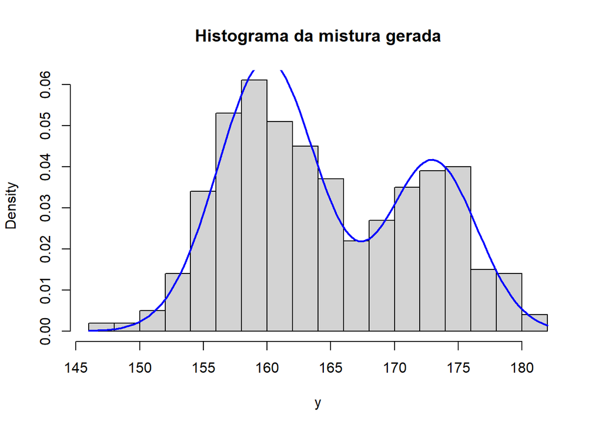

```r
#Fixando os parâmetros
P <- c(0.64,0.36)
mu <- c(160,173)
sigma <- sqrt(c(15,12))
n<- 500

grupos <- t(rmultinom(n, 1, prob=P))
y <- numeric(n)
for(i in 1:2)
  y[as.logical(grupos[,i])] <- rnorm(sum(grupos[,i]), mu[i],sigma[i])


hist(y,freq=F,breaks=20, main="Histograma da mistura gerada")
curve(P[1]*dnorm(x,mu[1],sigma[1]) + P[2]*dnorm(x,mu[2],sigma[2]),add=T,col="blue",lwd=2)
```

Agora, implementando o algoritmo EM como foi enunciado na Seção 2, temos:

```r
l <- function(p){
  sum(log(p[1]*dnorm(y,mu[1],sigma[1])+p[2]*dnorm(y,mu[2],sigma[2])))
}

crit <- function(ll,p){
  ll2 <- l(p)
  abs(ll2-ll)/(abs(ll) + 1e-8) > 1e-7
}

component <- function(x,g){
  dnorm(x,mu[g],sigma[g])
}

EM <- function(p){
  cont<-1
  l1<-100
  z <- 1
  while(crit(l1,p)){
    #--------PASSO E--------#
    z <- sapply(y,function(y){
      sapply(1:2,function(j) p[j]*component(y,j)/sum(p[1]*component(y,1),p[2]*component(y,2)))
    })
    #-----------------------#
    l1<- l(p)
    #--------PASSO M--------#
    p <- apply(z,1,mean)
    #-----------------------#
    cat("Iteração ",cont,": phat=",p,"\n")
    cont<-cont+1
  }
  return(p)
}

#chute inicial de equiprobabilidade
EM(c(0.5,0.5))
```

```
Iteração  1 : phat= 0.6213948 0.3786052
Iteração  2 : phat= 0.6357915 0.3642085
Iteração  3 : phat= 0.6375634 0.3624366
Iteração  4 : phat= 0.6377834 0.3622166
```

```
[1] 0.6377834 0.3622166
```

## 2.2. Exemplo: Mistura Normal com Duas Componentes (médias e variâncias desconhecidas)

Suponhamos que seja a mesma mistura em 2.1, mas dessa vez não se sabe os parâmetros das componentes (apenas o número de componentes). O passo E segue idêntico, mas agora o passo M envolve encontrar os estimadores de máxima verossimilhança de $\mu_1, \mu_2$ e $\sigma^2_1,\sigma^2_2$:

$$l_c(\bm \Psi)=
\sum^g_{j=1}\sum^n_{i=1}z_{ij}\left\{\log p_j-\frac{1}{2}\left[\log\sigma^2_j-\frac{(y_i-\mu_j)^2}{\sigma^2_j}\right]+c\right\},$$

onde $c$ é uma constante em relação a $\bm \Psi=(\bm p,\bm \mu,\bm \sigma)$. Logo, temos que:

$$\begin{aligned}
Q(\bm \Psi|\bm{\Psi\k{k}})&=\text E [l_c(\bm \Psi)|\bm y, \bm \Psi\k{k}]
\\
&=\sum^g_{j=1}\sum^n_{i=1}\hat z_{ij}\left\{\log p_j-\frac{1}{2}\left[\log\sigma^2_j+\frac{(y_i-\mu_j)^2}{\sigma^2_j}\right]+c\right\}
\end{aligned}$$

Logo, para o passo M:

$$\frac{dQ(\bm \Psi|\bm{\Psi\k{k}})}{d\mu_j}=\sum^n_{i=1}\hat z_{ij}\frac{(y_i-\mu_j)}{\sigma^2_j}$$

$$\Rightarrow \frac{\sum^n_{i=1}z_{ij}\k{k}(y_i-\mu_j\k{k+1})}{{\sigma^2_j}\k{k}}=0
\Rightarrow \sum^n_{i=1}\hat z_{ij}\k{k}y_i=\sum^n_{i=1}\hat z_{ij}\k{k}\mu_j\k{k+1}$$

$$\Rightarrow
\mu_j\k{k+1}=\frac{\sum^n_{i=1}\hat z_{ij}\k{k}y_i}{\sum^n_{i=1}\hat z_{ij}\k{k}}
\tag{1}$$

$$\frac{dQ(\bm \Psi|\bm{\Psi\k{k}})}{d\sigma^2_j}=
\sum^n_{i=1}z_{ij}\left[-\frac{1}{2\sigma^2_j}+\frac{(y_i-\mu_j)^2}{2({\sigma^2_j})^2}\right]$$

$$\Rightarrow \sum^n_{i=1}z_{ij}\k{k}\left[-\frac{1}{2{\sigma^2_j}\k{k+1}}+\frac{(y_i-\mu_j^{(k+ 1)})^2}{2({\sigma^2_j}\k{k+1})^2}\right]=0\Rightarrow
\frac{\sum^n_{i=1}z_{ij}\k{k}(y_i-\mu_j\k{k+1})^2}{{\sigma^2_j}\k{k+1}}=\sum^n_{i=1}z_{ij}\k{k}$$

Assim temos o seguinte algoritmo:

```r
#usando os mesmos dados do exemplo 2.1
l <- function(p,mu,sigma){
  sum(log(p[1]*dnorm(y,mu[1],sigma[1])+p[2]*dnorm(y,mu[2],sigma[2])))
}

crit <- function(ll,p,mu,sig){
  ll2 <- l(p,mu,sig)
  abs(ll2-ll)/(abs(ll) + 1e-8) > 1e-6
}

component <- function(x,mu,sig,g){
  dnorm(x,mu[g],sqrt(sig[g]))
}

EM <- function(p,mu,sig){
  cont<-1
  l1<-100
  z <- 1
  while(crit(l1,p,mu,sig)){
    #--------PASSO E--------#
    z <- sapply(y,function(y){
      sapply(1:2,function(j) p[j]*component(y,mu,sig,j)/sum(p[1]*component(y,mu,sig,1),
                                                            p[2]*component(y,mu,sig,2)))
    })
    #-----------------------#
    l1<- l(p,mu,sig)
    #--------PASSO M--------#
    p <- apply(z,1,mean)
    mu <- apply(z,1,function(z) sum(z*y)/sum(z))
    sig <- sapply(1:2, function(j)
      sum(z[j,]*(y-mu[j])^2)/sum(z[j,]))
    #-----------------------#
    cat("Iteração ",cont,": phat=",p," muhat= ", mu,"sigma2hat", sig,"\n")
    cont<-cont+1
  }
  return(cbind(p,mu,sig))
}

#chute baseado no histograma
EM(c(0.3,0.7),c(175,158),c(10,10))
```

```
Iteração  1 : phat= 0.3700584 0.6299416  muhat=  173.0612 159.6069 sigma2hat 11.74508 15.65242
Iteração  2 : phat= 0.3652876 0.6347124  muhat=  173.0345 159.7234 sigma2hat 12.62027 16.88024
Iteração  3 : phat= 0.3625774 0.6374226  muhat=  173.0465 159.7732 sigma2hat 12.77894 17.34076
Iteração  4 : phat= 0.360578 0.639422  muhat=  173.0687 159.8022 sigma2hat 12.74057 17.56622
Iteração  5 : phat= 0.3589327 0.6410673  muhat=  173.0921 159.8231 sigma2hat 12.64918 17.7071
Iteração  6 : phat= 0.3575169 0.6424831  muhat=  173.1142 159.8401 sigma2hat 12.54977 17.81274
Iteração  7 : phat= 0.3562778 0.6437222  muhat=  173.1341 159.8546 sigma2hat 12.45623 17.90037
Iteração  8 : phat= 0.3551869 0.6448131  muhat=  173.1518 159.8673 sigma2hat 12.37222 17.97639
Iteração  9 : phat= 0.3542247 0.6457753  muhat=  173.1675 159.8785 sigma2hat 12.29803 18.04347
Iteração  10 : phat= 0.353376 0.646624  muhat=  173.1813 159.8884 sigma2hat 12.23293 18.10299
Iteração  11 : phat= 0.3526278 0.6473722  muhat=  173.1934 159.8972 sigma2hat 12.17594 18.15585
Iteração  12 : phat= 0.3519684 0.6480316  muhat=  173.204 159.9049 sigma2hat 12.12608 18.20277
Iteração  13 : phat= 0.3513877 0.6486123  muhat=  173.2134 159.9118 sigma2hat 12.08248 18.24436
Iteração  14 : phat= 0.3508766 0.6491234  muhat=  173.2216 159.9178 sigma2hat 12.04433 18.28119
Iteração  15 : phat= 0.3504269 0.6495731  muhat=  173.2288 159.9231 sigma2hat 12.01096 18.31377
Iteração  16 : phat= 0.3500314 0.6499686  muhat=  173.2352 159.9278 sigma2hat 11.98176 18.34255
Iteração  17 : phat= 0.3496837 0.6503163  muhat=  173.2407 159.9319 sigma2hat 11.9562 18.36796
Iteração  18 : phat= 0.3493781 0.6506219  muhat=  173.2456 159.9356 sigma2hat 11.93382 18.39037
Iteração  19 : phat= 0.3491096 0.6508904  muhat=  173.2499 159.9388 sigma2hat 11.91422 18.41012
Iteração  20 : phat= 0.3488737 0.6511263  muhat=  173.2536 159.9416 sigma2hat 11.89706 18.42752
Iteração  21 : phat= 0.3486665 0.6513335  muhat=  173.2569 159.944 sigma2hat 11.88203 18.44284
Iteração  22 : phat= 0.3484846 0.6515154  muhat=  173.2598 159.9462 sigma2hat 11.86886 18.45631
Iteração  23 : phat= 0.3483249 0.6516751  muhat=  173.2624 159.9481 sigma2hat 11.85732 18.46817
Iteração  24 : phat= 0.3481847 0.6518153  muhat=  173.2646 159.9498 sigma2hat 11.84721 18.4786
Iteração  25 : phat= 0.3480616 0.6519384  muhat=  173.2666 159.9512 sigma2hat 11.83835 18.48776
Iteração  26 : phat= 0.3479536 0.6520464  muhat=  173.2683 159.9525 sigma2hat 11.83058 18.49581
Iteração  27 : phat= 0.3478587 0.6521413  muhat=  173.2698 159.9537 sigma2hat 11.82378 18.50289
Iteração  28 : phat= 0.3477756 0.6522244  muhat=  173.2711 159.9547 sigma2hat 11.81781 18.5091
Iteração  29 : phat= 0.3477025 0.6522975  muhat=  173.2722 159.9555 sigma2hat 11.81258 18.51456
Iteração  30 : phat= 0.3476385 0.6523615  muhat=  173.2733 159.9563 sigma2hat 11.80799 18.51935
Iteração  31 : phat= 0.3475823 0.6524177  muhat=  173.2742 159.957 sigma2hat 11.80397 18.52356
Iteração  32 : phat= 0.347533 0.652467  muhat=  173.2749 159.9576 sigma2hat 11.80045 18.52726
Iteração  33 : phat= 0.3474897 0.6525103  muhat=  173.2756 159.9581 sigma2hat 11.79736 18.5305
Iteração  34 : phat= 0.3474518 0.6525482  muhat=  173.2762 159.9585 sigma2hat 11.79465 18.53334
Iteração  35 : phat= 0.3474185 0.6525815  muhat=  173.2767 159.9589 sigma2hat 11.79227 18.53584
Iteração  36 : phat= 0.3473893 0.6526107  muhat=  173.2772 159.9593 sigma2hat 11.79019 18.53803
Iteração  37 : phat= 0.3473636 0.6526364  muhat=  173.2776 159.9596 sigma2hat 11.78836 18.53995
Iteração  38 : phat= 0.3473412 0.6526588  muhat=  173.278 159.9599 sigma2hat 11.78675 18.54164
Iteração  39 : phat= 0.3473215 0.6526785  muhat=  173.2783 159.9601 sigma2hat 11.78535 18.54312
Iteração  40 : phat= 0.3473042 0.6526958  muhat=  173.2786 159.9603 sigma2hat 11.78412 18.54442
Iteração  41 : phat= 0.347289 0.652711  muhat=  173.2788 159.9605 sigma2hat 11.78304 18.54556
Iteração  42 : phat= 0.3472757 0.6527243  muhat=  173.279 159.9607 sigma2hat 11.78209 18.54656
Iteração  43 : phat= 0.347264 0.652736  muhat=  173.2792 159.9608 sigma2hat 11.78126 18.54744
Iteração  44 : phat= 0.3472538 0.6527462  muhat=  173.2794 159.9609 sigma2hat 11.78053 18.54821
Iteração  45 : phat= 0.3472448 0.6527552  muhat=  173.2795 159.961 sigma2hat 11.77989 18.54888
Iteração  46 : phat= 0.3472369 0.6527631  muhat=  173.2796 159.9611 sigma2hat 11.77933 18.54947
Iteração  47 : phat= 0.34723 0.65277  muhat=  173.2797 159.9612 sigma2hat 11.77883 18.54999
Iteração  48 : phat= 0.347224 0.652776  muhat=  173.2798 159.9613 sigma2hat 11.7784 18.55045
Iteração  49 : phat= 0.3472186 0.6527814  muhat=  173.2799 159.9613 sigma2hat 11.77802 18.55085
Iteração  50 : phat= 0.347214 0.652786  muhat=  173.28 159.9614 sigma2hat 11.77769 18.5512
Iteração  51 : phat= 0.3472099 0.6527901  muhat=  173.28 159.9614 sigma2hat 11.7774 18.55151
Iteração  52 : phat= 0.3472063 0.6527937  muhat=  173.2801 159.9615 sigma2hat 11.77715 18.55177
Iteração  53 : phat= 0.3472032 0.6527968  muhat=  173.2802 159.9615 sigma2hat 11.77692 18.55201
Iteração  54 : phat= 0.3472004 0.6527996  muhat=  173.2802 159.9616 sigma2hat 11.77673 18.55222
Iteração  55 : phat= 0.347198 0.652802  muhat=  173.2802 159.9616 sigma2hat 11.77655 18.5524
Iteração  56 : phat= 0.3471959 0.6528041  muhat=  173.2803 159.9616 sigma2hat 11.7764 18.55256
```

```
             p       mu      sig
[1,] 0.3471959 173.2803 11.77640
[2,] 0.6528041 159.9616 18.55256
```

## 2.3. Exemplo: Mistura T de Student com graus de liberdade desconhecidos.

Suponhamos que haja uma mistura $p_1t(\mu_1,\sigma_1,\nu_1)+p_2t(\mu_2,\sigma_2,\nu_2)$. McLachlan; Krishnan (2008) apresenta uma implementação do algoritmo ECM para estimação de misturas t-Student que realiza uma decomposição similar ao exemplo do documento `AlgoritmoEM.html`. Assim, a t de Student é escrita como $Y_i = \mu + U^{-1/2}Z$, onde $Z\sim N(0,\sigma^2) \perp\!\!\!\perp U\sim \text{Gama}(\nu/2,\nu/2)$ e o conjunto de parâmetros é subdividido como $\bm\Psi=(\bm p,\bm\theta_1,\bm\theta_2)$, onde $\bm\theta_1=(\bm\mu,\bm\sigma^2)$ e $\bm\theta_2=\bm\nu$. Assim, temos que a função $Q$ também pode ser subdividida como:

$$Q(\bm \Psi|\bm{\Psi\k{k}})=Q_1(\bm p|\bm{\Psi\k{k}})+Q_2(\bm\theta_1|\bm{\Psi\k{k}})+Q_3(\bm\theta_2|\bm{\Psi\k{k}}),$$
onde:

$$Q_1(\bm p|\bm{\Psi\k{k}})=\sum^n_{i=1}\sum^g_{j=1}\hat z_{ij}p_{j}$$

$$Q_2(\bm\theta_1|\bm{\Psi\k{k}})=
\frac{1}{2}\sum^n_{i=1}\sum^g_{j=1}\hat z_{ij}\left\{
\log(2\pi)-\sum^g_{k=1}\log(\sigma_k^2)+\log\hat u_{ij}\k{k}-\hat u_{ij}\sum^g_{k=1}d^2_{Mi}(y_i,\mu_k,\sigma^2_k)\right\}$$
$$Q_3(\bm\theta_2|\bm{\Psi\k{k}})=\sum^n_{i=1}\sum^g_{j=1}\hat z_{ij}\left\{
-\log\Gamma(\nu_i/2)
+ \frac{\nu_i}{2}
\left[
\log(\nu_i/2)+\sum^n_{i=1}\left(
\log(\hat u_{ij}\k{k}) - \hat u_{ij}\k{k}
\right)+
\psi\left(\frac{\nu_i\k{k}+1}{2}\right)-
\log\left(\frac{\nu_i\k{k}+1}{2}\right)
\right]
\right\}$$

Onde $d_{Mi}^2(y_i,\mu,\sigma^2)=\frac{(y_i-\mu)^2}{\sigma^2}$.

O algoritmo, então, é:

1. **Passo E**: Calcula-se:
   $$\hat z_{ij}\k{k}=\frac{p_{j}\k{k} f_j(y_i|\mu_j\k{k}, {\sigma_j^2}\k{k}, \nu_j\k{k})}{\sum^g_{h=1} p_h\k{k}f_h(y_i|\mu_j\k{k},{\sigma_j^2}\k{k},\nu_j\k{k})},\quad i=1,...,n\quad j=1,...,g;$$
   $$\hat u_{ij}\k{k}=\frac{\hat\nu^{(k)}+1}{\hat\nu^{(k)}+d^2_{Mij}(y_i,\mu_j\k k,{\sigma_j^2}\k k)},\quad i=1,2,...,n.$$
2. **Passo CM-1**: Obtém-se $\bm\theta_1\k{k+1}$ maximizando $Q(\bm\Psi|\bm\Psi\k{k})$ com $\bm\theta_2$ fixado ($\bm\nu=\bm\nu\k{k}$). Ou seja, maximiza-se $Q_2(\bm\theta_1|\bm{\Psi\k{k}})$.
3. **Passo CM-1**: Obtém-se $\bm\theta_2\k{k+1}$ maximizando $Q(\bm\Psi|\bm\Psi\k{k})$ com $\bm\theta_1=\bm\theta_1\k{k+1}$ fixado. Ou seja, maximiza-se $Q_3(\bm\theta_2|\bm{\Psi\k{k}})$.
4. Verifica-se se o critério de parada. Caso seja falso, retorna-se ao passo 1.

## Referências

BASSO, R. M.; DÁVILA, V. H. L. **Misturas finitas de misturas de escala skew-normal**. tese de doutorado—SP: Dissertação de Mestrado-Universidade Estadual de Campinas, 2010.

MCLACHLAN, G. J.; KRISHNAN, T. **The EM algorithm and extensions**. [s.l.] John Wiley & Sons, 2008.